[figure not shown]

# How to Win in DOTA 2 If You're a Data Scientist

##### Brian Chin, Allison Wei, Dan Zou

## Background

Dota 2 is a multiplayer online battle arena (MOBA) game developed and published by Valve. The game is a sequel to Defense of the Ancients (DotA), and is played in matches between two teams of five players (5 vs. 5), with each team occupying and defending their own separate base on the map. Each of the ten players independently controls a powerful character, known as a "hero", who all have unique abilities and differing styles of play (only one of each hero in each match). During a match, players collect experience points and items for their heroes to successfully defeat the opposing team's heroes in player versus player combat. A team wins by being the first to destroy the other team's "Ancient", a large structure located within their base. More info [here.](https://en.wikipedia.org/wiki/Dota_2)

We are looking at a dataset pulled through using da-steve101's Dota 2 api loader found [here.](https://gist.github.com/da-steve101/1a7ae319448db431715bd75391a66e1b) The dataset (hosted on UCI's [ML repository](https://archive.ics.uci.edu/ml/datasets/Dota2+Games+Results#)) are of games which were played in a span of 2 hours on the August 13th, 2016. This data contains the result of which team has lost and which team has won, the regions, the game types, the heros that were chosen.

In this tutorial, our mission is to tidy the data, and provide insight onto which 5 heros are the most successful in terms of the win rate, and which hero choices will result in the highest win rate in each game (similar to what was done in this UC San Diego [study](http://jmcauley.ucsd.edu/cse255/projects/fa15/018.pdf). In this game, each hero (111 total) have different skills and roles which would allow for very different combinations of teams. With our analysis we hope to find our if it is possible to find teams that are more successful than others, and have a higher probability of winning. For readers that are unfamiliar, or are just getting into the game, we hope that our analysis will either make them more interested in Dota 2, or help provide some information on which heros to pick in certain lineups. For people who have more experience in the game, this may help them choose better heros for the meta (most effective tactics available).

## Importing and Preparation

We'll be using multiple different libraries to process and display our data. We'll be using urllib and requests to access data from the internet. Processing will occur with pandas, numpy, statsmodel, and sklearn. Finally, visualizations will be performed by matplotlib, seaborn, and yellowbrick (more on yellowbrick later).

```python
%matplotlib inline
```

```python
import requests
import numpy as np
import sklearn as sk
import pandas as pd
import requests
import json
import matplotlib.pyplot as plt
import seaborn as sns
from io import BytesIO
from zipfile import ZipFile
from urllib.request import urlopen
from sklearn import svm
from sklearn.linear_model import LogisticRegression
from sklearn.neural_network import MLPRegressor, MLPClassifier
from yellowbrick.model_selection import LearningCurve
from sklearn.model_selection import KFold
import statsmodels.api as sm
```

UCI conveniently [hosts](https://archive.ics.uci.edu/ml/datasets/Dota2+Games+Results#) the results of some 100,000 games played on August 13th. The data includes win/loss result, game region, game type, and player types. It's also pre split into a training set and a testing set. The data is stored as a zip on UCI's servers, so we'll use the zipfile library to extract the files from it.

```python
url = urlopen("https://archive.ics.uci.edu/ml/machine-learning-databases/00367/dota2Dataset.zip")
zipfile = ZipFile(BytesIO(url.read()))
zipfile.namelist()
```

```
['dota2Train.csv', 'dota2Test.csv']
```

```python
# opening files like this is bad form but whatever
training_file = zipfile.open('dota2Train.csv')
testing_file = zipfile.open('dota2Test.csv')
train_df = pd.read_csv(training_file, header=None)
test_df = pd.read_csv(testing_file, header=None)
len(train_df), len(test_df)
```

```
(92650, 10294)
```

The training data contains more than 90,000 observations, with the testing data containing over 10,000. This is plenty for what we're doing, and we'll in fact be filtering out a significant portion of it later.

Before continuing, we'll have to prepare the datasets. As it stands, the dataset has no column names, and all of the categorical data uses magic numbers instead of their actual names. We'll apply the same transformations to both datasets as we'll have to verify our results on the testing dataframe later.

```python
train_df.head(5)
```

|  | 0 | 1 | 2 | 3 | 4 | 5 | 6 | 7 | 8 | 9 | ... | 107 | 108 | 109 | 110 | 111 | 112 | 113 | 114 | 115 | 116 |
| --- | --- | --- | --- | --- | --- | --- | --- | --- | --- | --- | --- | --- | --- | --- | --- | --- | --- | --- | --- | --- | --- |
| 0 | -1 | 223 | 2 | 2 | 0 | 0 | 0 | 0 | 0 | 0 | ... | 0 | 0 | 0 | 0 | 0 | 0 | 0 | 0 | 0 | 0 |
| 1 | 1 | 152 | 2 | 2 | 0 | 0 | 0 | 1 | 0 | -1 | ... | 0 | 0 | 0 | 0 | 0 | 0 | 0 | 0 | 0 | 0 |
| 2 | 1 | 131 | 2 | 2 | 0 | 0 | 0 | 1 | 0 | -1 | ... | 0 | 0 | 0 | 0 | 0 | 0 | 0 | 0 | 0 | 0 |
| 3 | 1 | 154 | 2 | 2 | 0 | 0 | 0 | 0 | 0 | 0 | ... | -1 | 0 | 0 | 0 | 0 | 0 | 0 | 0 | 0 | 0 |
| 4 | -1 | 171 | 2 | 3 | 0 | 0 | 0 | 0 | 0 | -1 | ... | 0 | 0 | 0 | 0 | 0 | 0 | 0 | 0 | 0 | 0 |

5 rows × 117 columns

In the data, the first row is for which team won (so in effect we have two times the data, because we can extract which 5 set of heros resulted in a loss, and which resulted in a win), with 1 being Radiant winning, and -1 for Dire winning. The next column (column 1) is the region of the world that the game data occured, and the following two rows are the game types that were played from All Pick to Greeviling (More explination [here](https://dota2.gamepedia.com/Game_modes) or [here](https://liquipedia.net/dota2/Game_Modes)). From column 4 onwards to 116, are the different heros as listed in this [database](https://github.com/kronusme/dota2-api/blob/master/data/heroes.json). Note that number 24 is missing for unknown reasons (there is no data in that row as well as no hero existing for that number either). Furthermore, the hero Abyssal Underlord was not patched in at this time, so no data exists either for that id (108). The keys for all this data was found [here](https://github.com/kronusme/dota2-api/tree/master/data) under "lobbies," "mods," and "heroes."

### Heroes:

[figure not shown]

Data on the magic numbers can be found at kronusme/dota2-api. We can then extract the mapping from each JSON file to produce a dictionary of replacements to later be given to `replace`.

```python
request = requests.get('https://raw.githubusercontent.com/kronusme/dota2-api/master/data/mods.json')
parsed = request.json()
tmp_df = pd.DataFrame.from_dict(parsed)
mods_replace = dict([(row['id'], row['name']) for row in tmp_df[tmp_df.columns[0]]])

request = requests.get('https://raw.githubusercontent.com/kronusme/dota2-api/master/data/lobbies.json')
parsed = request.json()
tmp_df = pd.DataFrame.from_dict(parsed)
lobbies_replace = dict([(row['id'], row['name']) for row in tmp_df[tmp_df.columns[0]]])

request = requests.get('https://raw.githubusercontent.com/kronusme/dota2-api/master/data/regions.json')
parsed = request.json()
tmp_df = pd.DataFrame.from_dict(parsed)
regions_replace = dict([(row['id'], row['name']) for row in tmp_df[tmp_df.columns[0]]])
regions_replace[232] = 'China'

lobbies_replace
```

```
{-1: 'Invalid',
 0: 'Public matchmaking',
 1: 'Practice',
 2: 'Tournament',
 3: 'Tutorial',
 4: 'Co-op with bots',
 5: 'Team match',
 6: 'Solo Queue',
 7: 'Ranked',
 8: 'Solo Mid 1vs1'}
```

We also need to correct the column names. The first four columns are Win/Lose, Server ID, Match Type, and Game Lobby.

For the remaining hero columns, we will use the same repository to extract the heroes' name that correspond to each column. We have to take care with how we extract the heroes' names from the json file because they are not sorted by ID (We're not sure how they're sorted, really).

```python
request = requests.get('https://raw.githubusercontent.com/kronusme/dota2-api/master/data/heroes.json')
parsed = request.json()
heroes_df = pd.DataFrame(parsed['heroes']).set_index('id')

heroes_list = []
for i in range(1, 114):
    if i in heroes_df.index:
        heroes_list.append(heroes_df.loc[i]['localized_name'])
    else:
        heroes_list.append("Unassigned")
```

```python
columns = ['Win/Lose', 'Server ID', 'Match Type', 'Game Lobby'] + heroes_list

train_df.columns = columns
test_df.columns = columns
train_df.head(5)
```

|  | Win/Lose | Server ID | Match Type | Game Lobby | Anti-Mage | Axe | Bane | Bloodseeker | Crystal Maiden | Drow Ranger | ... | Legion Commander | Techies | Ember Spirit | Earth Spirit | Abyssal Underlord | Terrorblade | Phoenix | Oracle | Winter Wyvern | Arc Warden |
| --- | --- | --- | --- | --- | --- | --- | --- | --- | --- | --- | --- | --- | --- | --- | --- | --- | --- | --- | --- | --- | --- |
| 0 | -1 | 223 | 2 | 2 | 0 | 0 | 0 | 0 | 0 | 0 | ... | 0 | 0 | 0 | 0 | 0 | 0 | 0 | 0 | 0 | 0 |
| 1 | 1 | 152 | 2 | 2 | 0 | 0 | 0 | 1 | 0 | -1 | ... | 0 | 0 | 0 | 0 | 0 | 0 | 0 | 0 | 0 | 0 |
| 2 | 1 | 131 | 2 | 2 | 0 | 0 | 0 | 1 | 0 | -1 | ... | 0 | 0 | 0 | 0 | 0 | 0 | 0 | 0 | 0 | 0 |
| 3 | 1 | 154 | 2 | 2 | 0 | 0 | 0 | 0 | 0 | 0 | ... | -1 | 0 | 0 | 0 | 0 | 0 | 0 | 0 | 0 | 0 |
| 4 | -1 | 171 | 2 | 3 | 0 | 0 | 0 | 0 | 0 | -1 | ... | 0 | 0 | 0 | 0 | 0 | 0 | 0 | 0 | 0 | 0 |

5 rows × 117 columns

We will also drop two columns, the column associated with ID 24 and the column associated Abyssal Underlord. As explained above, for unexplained reasons, Valve never assigned a hero to ID 24. Nevertheless, due to how the data was generated, a 24th hero column exists, but is simply populated with zeroes. We will also drop the column associated with Abyssal Underlord. At the time of the data's generation, Abyssal Underlord was an unreleased hero, but a column for him for exists in the dataset anyway as his ID is smaller than the IDs of heroes that had already been released. As such, the column associated with Abyssal Underlord is also filled with zeroes.

```python
train_df = train_df.drop(["Unassigned", "Abyssal Underlord"], axis=1)
test_df = test_df.drop(["Unassigned", "Abyssal Underlord"], axis=1)
columns.remove("Unassigned")
columns.remove("Abyssal Underlord")
heroes_list.remove("Unassigned")
heroes_list.remove("Abyssal Underlord")
```

The Server ID will be mapped using the `regions_replace` dictionary, but in order to avoid losing the specificity of the server ID, an extra column, Region, will be created instead of outright replacing the Server ID column. Match Type and Game Lobby correspond to `mods_replace` and `lobbies_replace`, respectively.

We're also interested in Captain's Mode Tournament games, so we'll filter those out now as well.

```python
train_df.insert(1, 'Region', train_df['Server ID'].replace(regions_replace))
train_df['Match Type'] = train_df['Match Type'].replace(mods_replace)
train_df['Game Lobby'] = train_df['Game Lobby'].replace(lobbies_replace)
train_df = train_df[(train_df['Game Lobby'] == 'Tournament') & (train_df['Match Type'] == 'Captains Mode')]

test_df.insert(1, 'Region', test_df['Server ID'].replace(regions_replace))
test_df['Match Type'] = test_df['Match Type'].replace(mods_replace)
test_df['Game Lobby'] = test_df['Game Lobby'].replace(lobbies_replace)
test_df = test_df[(test_df['Game Lobby'] == 'Tournament') & (test_df['Match Type'] == 'Captains Mode')]

columns.insert(1, 'Region')

train_df.head(5)
```

|  | Win/Lose | Region | Server ID | Match Type | Game Lobby | Anti-Mage | Axe | Bane | Bloodseeker | Crystal Maiden | ... | Elder Titan | Legion Commander | Techies | Ember Spirit | Earth Spirit | Terrorblade | Phoenix | Oracle | Winter Wyvern | Arc Warden |
| --- | --- | --- | --- | --- | --- | --- | --- | --- | --- | --- | --- | --- | --- | --- | --- | --- | --- | --- | --- | --- | --- |
| 0 | -1 | China | 223 | Captains Mode | Tournament | 0 | 0 | 0 | 0 | 0 | ... | 0 | 0 | 0 | 0 | 0 | 0 | 0 | 0 | 0 | 0 |
| 1 | 1 | Southeast Asia | 152 | Captains Mode | Tournament | 0 | 0 | 0 | 1 | 0 | ... | 0 | 0 | 0 | 0 | 0 | 0 | 0 | 0 | 0 | 0 |
| 2 | 1 | Europe West | 131 | Captains Mode | Tournament | 0 | 0 | 0 | 1 | 0 | ... | 0 | 0 | 0 | 0 | 0 | 0 | 0 | 0 | 0 | 0 |
| 3 | 1 | Southeast Asia | 154 | Captains Mode | Tournament | 0 | 0 | 0 | 0 | 0 | ... | 0 | -1 | 0 | 0 | 0 | 0 | 0 | 0 | 0 | 0 |
| 9 | -1 | Southeast Asia | 151 | Captains Mode | Tournament | 0 | 0 | 0 | 1 | 0 | ... | 0 | 0 | 0 | 1 | 0 | 0 | 0 | 0 | 0 | 0 |

5 rows × 116 columns

As explained above, we split up the teams into losers and winners for the two different team types: 1 for Radiant and -1 for Dire, so that we would have, essentially, two times the heroes to win/loss data. Instead of giving us data on matches with which team won or loss, we now have data on matches and whether the team won or loss.

```python
tmp_df = train_df.replace({1:0}).replace({-1:1})
tmp_df.insert(1, 'Team', 'Dire')
train_df = train_df.replace({-1:0})
train_df.insert(1, 'Team', 'Radiant')
train_df = train_df.append(tmp_df)

tmp_df = test_df.replace({1:0}).replace({-1:1})
tmp_df.insert(1, 'Team', 'Dire')
test_df = test_df.replace({-1:0})
test_df.insert(1, 'Team', 'Radiant')
test_df = test_df.append(tmp_df)

columns.insert(1, 'Team')
```

```python
train_df = train_df.sample(frac=1).reset_index(drop=True)
test_df = test_df.sample(frac=1).reset_index(drop=True)
```

## Preliminary Investigation

### Win Rates By Hero

One natural question is, do certain heroes win more often than others? We can easily extract the win rates for each hero by summing the number of times they win and dividing by the number of matches they're in.

```python
win_loss_count = train_df.groupby('Win/Lose').sum().iloc[:, -len(heroes_list):]
totals = win_loss_count.sum()
win_proportion = (win_loss_count.iloc[1] / totals).sort_values()
win_proportion
```

```
Wisp                 0.349227
Broodmother          0.350559
Enchantress          0.370489
Lone Druid           0.388889
Visage               0.397993
                       ...
Necrophos            0.561204
Skeleton King        0.565600
Centaur Warrunner    0.567044
Elder Titan          0.602637
Omniknight           0.607831
Length: 111, dtype: float64
```

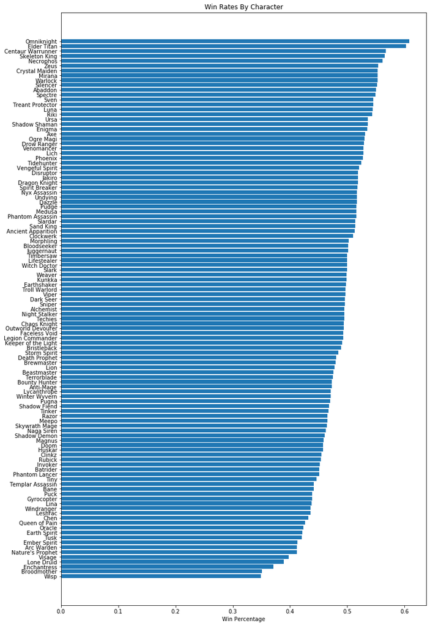

```python
fig, ax = plt.subplots(figsize=(12,20))
ax.barh(win_proportion.index, win_proportion)
ax.set_xlabel('Win Percentage')
ax.set_title('Win Rates By Character')
fig.show()
```

Okay...that's admittedly not that readable considering there are 111 heroes. Fortunately, we *can* tell that there's some characters that win quite a bit more than others. What if we kept just the top 5 and bottom 5?

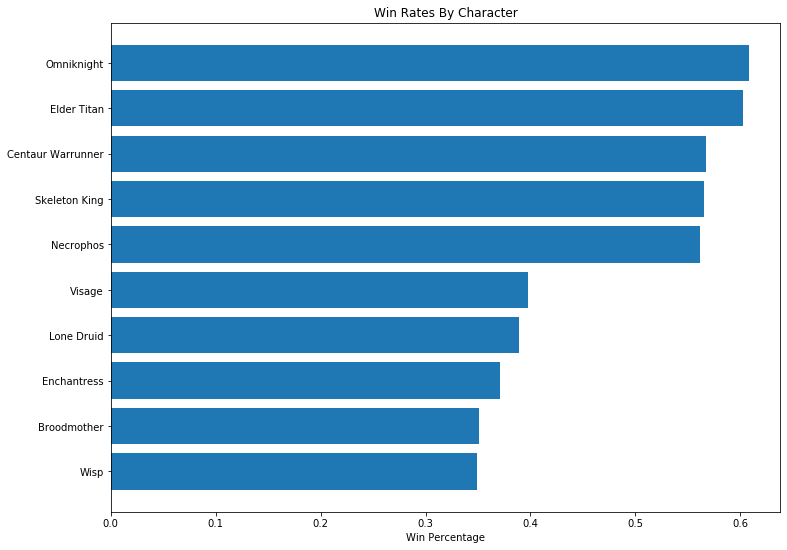

```python
fig, ax = plt.subplots(figsize=(12,9))
ax.barh(list(win_proportion.index[:5]) + list(win_proportion.index[-5:]), list(win_proportion[:5]) + list(win_proportion[-5:]))
ax.set_xlabel('Win Percentage')
ax.set_title('Win Rates By Character')
fig.show()
```

It's fairly obvious here that there's a significant difference in win rates between the top 5 and bottom 5 in our dataset. Then, do players select these top 5 players more often?

First, we'll resort our series by index so each value in totals correctly corresponds to a value in win_proportion.

```python
totals = totals.sort_index()
win_proportion = win_proportion.sort_index()
```

We'll also apply ordinary least squares to see whether or not there's a linear relationship in the data.

```python
y = totals
X = win_proportion
ols = sm.OLS(y, sm.add_constant(X))
ols_result = ols.fit()
(m, b) = ols_result.params[0], ols_result.params['const']
(m, b)
```

```
(17493.231716782, -4839.466853082906)
```

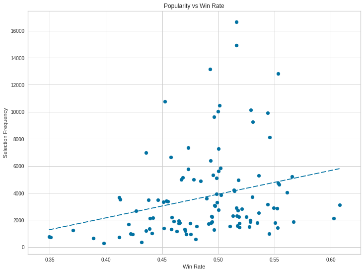

```python
fig, ax = plt.subplots(figsize=(12,9))
ax.scatter(win_proportion, totals)

# Plot OLS line
ax.plot(np.linspace(min(X), max(X), 10), b + m * np.linspace(min(X), max(X), 10), dashes=[6,2])

ax.set_title("Popularity vs Win Rate")
ax.set_xlabel("Win Rate")
ax.set_ylabel("Selection Frequency")
fig.show()
```

While there *is* a positive trend between win rate and selection frequency, there's a ton of variation. Furthermore, some of the highest winning heroes are also the least frequently selected. Looking closelier, we can check the r squared for the proportion of the variance of the selection frequency that can be explained by the win rate.

```python
ols_result.summary()
```

OLS Regression Results

| Dep. Variable: | y | R-squared: | 0.070 |
| --- | --- | --- | --- |
| Model: | OLS | Adj. R-squared: | 0.062 |
| Method: | Least Squares | F-statistic: | 8.220 |
| Date: | Mon, 16 Dec 2019 | Prob (F-statistic): | 0.00497 |
| Time: | 17:16:26 | Log-Likelihood: | -1049.2 |
| No. Observations: | 111 | AIC: | 2102. |
| Df Residuals: | 109 | BIC: | 2108. |
| Df Model: | 1 |  |  |
| Covariance Type: | nonrobust |  |  |

|  | coef | std err | t | P>\|t\| | [0.025 | 0.975] |
| --- | --- | --- | --- | --- | --- | --- |
| const | -4839.4669 | 2998.054 | -1.614 | 0.109 | -1.08e+04 | 1102.579 |
| 0 | 1.749e+04 | 6101.486 | 2.867 | 0.005 | 5400.286 | 2.96e+04 |

| Omnibus: | 48.283 | Durbin-Watson: | 2.195 |
| --- | --- | --- | --- |
| Prob(Omnibus): | 0.000 | Jarque-Bera (JB): | 106.816 |
| Skew: | 1.781 | Prob(JB): | 6.39e-24 |
| Kurtosis: | 6.226 | Cond. No. | 25.6 |

Warnings:  
[1] Standard Errors assume that the covariance matrix of the errors is correctly specified.

Wow! Our r-squared is only 0.07. It looks like there isn't a strong relationship between the selection frequency and the win-rate after all. One reason this might be is that heroes with higher win rates are simply harder to play and require more skill, making them less likely to be chosen. However, when chosen, they do very well. In the middle of our plot, we see the heroes that are most frequently chosen, likely because they're easier to master, and thus the playing ground is roughly level among all the people who select the hero, leading to about a 50% win rate.

### Region Specific Trends

As a multiplayer game with reach across the globe, Valve hosts servers for DOTA 2 gameplay in multiple regions and countries. Are there any region specific trends? We begin our analysis by grouping our data by region.

```python
by_region = train_df.groupby('Region').sum().drop('Server ID', axis=1)
by_region
```

| Region | Win/Lose | Anti-Mage | Axe | Bane | Bloodseeker | Crystal Maiden | Drow Ranger | Earthshaker | Juggernaut | Mirana | ... | Elder Titan | Legion Commander | Techies | Ember Spirit | Earth Spirit | Terrorblade | Phoenix | Oracle | Winter Wyvern | Arc Warden |
| --- | --- | --- | --- | --- | --- | --- | --- | --- | --- | --- | --- | --- | --- | --- | --- | --- | --- | --- | --- | --- | --- |
| Australia | 569 | 60 | 117 | 24 | 67 | 88 | 136 | 65 | 113 | 211 | ... | 22 | 161 | 30 | 53 | 17 | 29 | 34 | 19 | 19 | 11 |
| Chile | 101 | 17 | 30 | 5 | 8 | 10 | 15 | 10 | 21 | 21 | ... | 2 | 26 | 8 | 9 | 5 | 8 | 2 | 5 | 5 | 3 |
| China | 10069 | 1532 | 2458 | 221 | 843 | 907 | 1806 | 1410 | 2976 | 4040 | ... | 1118 | 2934 | 392 | 865 | 217 | 396 | 503 | 261 | 324 | 104 |
| Europe East | 616 | 89 | 146 | 21 | 89 | 91 | 136 | 48 | 131 | 122 | ... | 21 | 195 | 31 | 51 | 21 | 29 | 18 | 13 | 20 | 22 |
| Europe West | 1918 | 334 | 413 | 62 | 297 | 283 | 400 | 162 | 395 | 461 | ... | 65 | 639 | 115 | 159 | 55 | 89 | 78 | 55 | 66 | 60 |
| India | 148 | 20 | 35 | 8 | 38 | 15 | 50 | 14 | 29 | 27 | ... | 3 | 48 | 7 | 14 | 2 | 11 | 5 | 4 | 7 | 3 |
| Peru | 81 | 5 | 22 | 1 | 26 | 11 | 22 | 11 | 16 | 20 | ... | 1 | 27 | 6 | 2 | 1 | 4 | 3 | 0 | 1 | 1 |
| Russia | 3714 | 558 | 775 | 148 | 612 | 553 | 810 | 293 | 750 | 727 | ... | 91 | 1167 | 244 | 328 | 121 | 147 | 150 | 112 | 118 | 142 |
| South Africa | 87 | 6 | 32 | 6 | 15 | 11 | 14 | 3 | 16 | 34 | ... | 6 | 25 | 5 | 6 | 4 | 3 | 6 | 8 | 6 | 3 |
| South America | 637 | 99 | 173 | 25 | 88 | 90 | 104 | 68 | 136 | 192 | ... | 27 | 178 | 47 | 40 | 17 | 22 | 31 | 24 | 25 | 16 |
| South Korea | 1255 | 244 | 257 | 21 | 207 | 134 | 379 | 191 | 312 | 353 | ... | 43 | 409 | 70 | 109 | 21 | 47 | 30 | 24 | 35 | 21 |
| Southeast Asia | 20211 | 4144 | 4360 | 422 | 3333 | 2309 | 5851 | 2650 | 5195 | 6028 | ... | 626 | 6773 | 1135 | 1747 | 452 | 906 | 543 | 329 | 506 | 289 |
| US East | 1051 | 137 | 269 | 33 | 148 | 128 | 212 | 107 | 234 | 326 | ... | 52 | 334 | 93 | 81 | 27 | 44 | 44 | 46 | 50 | 34 |
| US West | 772 | 96 | 179 | 39 | 76 | 113 | 192 | 85 | 163 | 259 | ... | 47 | 228 | 58 | 55 | 31 | 25 | 50 | 44 | 25 | 22 |

14 rows × 112 columns

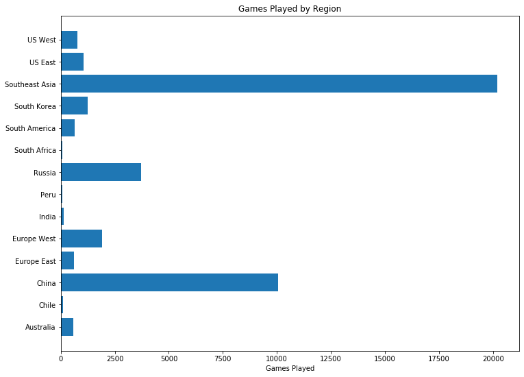

```python
fig, ax = plt.subplots(figsize=(12,9))
ax.barh(by_region.index, by_region['Win/Lose'])
ax.set_xlabel('Games Played')
ax.set_title('Games Played by Region')
fig.show()
```

The southeast Asia region absolutely dominates the other regions in number of games played. It's important to note however that the data was collected over a two time span on a single day. It's not mentioned what time of day that is, so the signficant bias towards Souteast Asia could simply be due to when the data was collected and not completely because of the game's popularity in Asia.

We will work with proportions instead of absolute counts, so for the sake of simplicity, we will assume that the two hours of gameplay data is representative of gameplay behavior overall, aside from absolute regional distribution characteristics like games played.

One trend we may be interested in is whether certain characters are selected more frequently than others. We can investigate this trend by first finding the proportion of times each hero is selected. We then find the standard deviation of the relative selection frequencies for each hero with respect to the regions. Larger standard deviations suggest that that character's selection frequency is more varied.

```python
hero_frq = by_region.apply(lambda r: r[-len(heroes_list):] / r[0] / 10, axis=1)
hero_std = hero_frq.std().sort_values()
hero_std
```

```
Lone Druid          0.000651
Chen                0.000821
Brewmaster          0.000824
Arc Warden          0.000928
Tusk                0.000967
                      ...
Huskar              0.006500
Sniper              0.006899
Riki                0.007030
Mirana              0.007395
Phantom Assassin    0.008596
Length: 111, dtype: float64
```

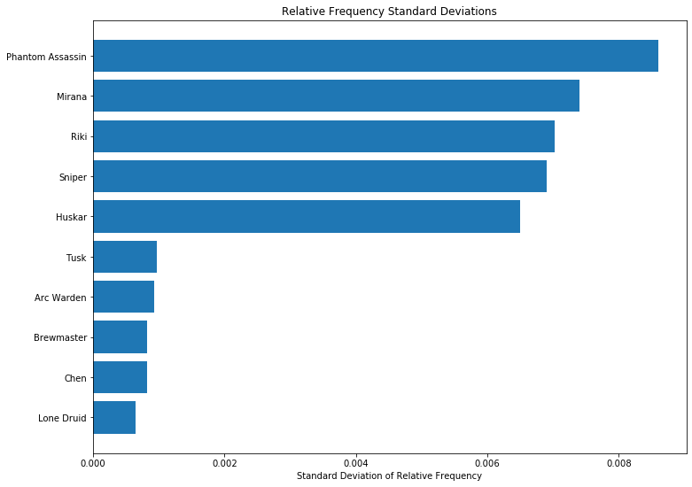

```python
fig, ax = plt.subplots(figsize=(12,9))
ax.barh(list(hero_std.index[:5]) + list(hero_std.index[-5:]), list(hero_std[:5]) + list(hero_std[-5:]))
ax.set_xlabel('Standard Deviation of Relative Frequency')
ax.set_title('Relative Frequency Standard Deviations')
fig.show()
```

While this is helpful in determining which heroes have the most varied selection frequency, we don't know which regions are selecting them more often. We can use a heatmap to visualize which regions select certain heroes more often than others. Below, we use a seaborn heatmap to display the three least varied and the 15 most varied heroes.

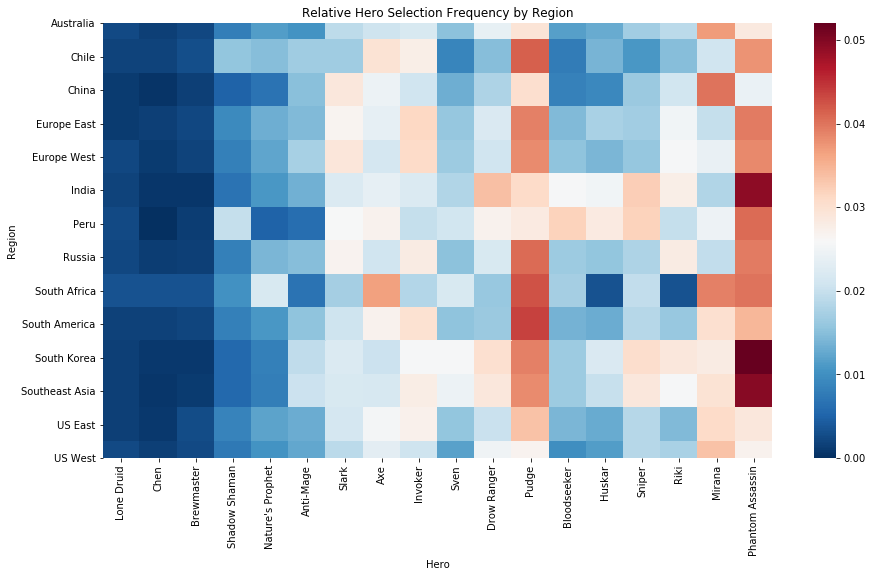

```python
fig, ax = plt.subplots(figsize=(15,8))
sns.heatmap(hero_frq[list(hero_std.index[:3]) + list(hero_std.index[-15:])], ax=ax, cmap="RdBu_r")
ax.set_xlabel("Hero")
ax.set_title("Relative Hero Selection Frequency by Region")
fig.show()
```

It looks like the least varied hero selection frequencies is simply due to them not being selected at all; their selection frequency is very close to zero.

The hero with the largest selection frequency variation is Phantom Assassin. It looks like the character is heavily preferred in South Korea, Southeast Asia, and India with nearly 5% of matches containing Phantom Assassin. Interestingly, in China, it's less preferred. When examining some other heroes like Huskar and Riki, we see that their high variance is caused by South Africa strongly preferring not to use the hero, with close to 0% of matches containing Huskar and Riki there.

A misleading aspect here is that some characters are simply less popular than others. If a character is less popular, then the standard deviation will be smaller. We can try to compensate for this by scaling the data so that the frequency mean is all the same, and then remeasuring variance.

```python
hero_mean = hero_frq.mean()
scaled_hero = hero_frq.apply(lambda r: r[-len(heroes_list):] / hero_mean, axis=1)
scaled_hero.head(5)
```

| Region | Anti-Mage | Axe | Bane | Bloodseeker | Crystal Maiden | Drow Ranger | Earthshaker | Juggernaut | Mirana | Morphling | ... | Elder Titan | Legion Commander | Techies | Ember Spirit | Earth Spirit | Terrorblade | Phoenix | Oracle | Winter Wyvern | Arc Warden |
| --- | --- | --- | --- | --- | --- | --- | --- | --- | --- | --- | --- | --- | --- | --- | --- | --- | --- | --- | --- | --- | --- |
| Australia | 0.749307 | 0.831142 | 1.148763 | 0.748568 | 1.215057 | 1.049022 | 1.094356 | 0.910703 | 1.310705 | 1.034313 | ... | 0.930799 | 0.922466 | 0.843565 | 1.191105 | 1.046360 | 1.094684 | 1.428442 | 0.970744 | 0.908692 | 0.776190 |
| Chile | 1.196047 | 1.200608 | 1.348280 | 0.503544 | 0.777866 | 0.651820 | 0.948498 | 0.953473 | 0.734907 | 1.120572 | ... | 0.476710 | 0.839245 | 1.267297 | 1.139482 | 1.733777 | 1.701264 | 0.473374 | 1.439170 | 1.347175 | 1.192580 |
| China | 1.081168 | 0.986727 | 0.597775 | 0.532243 | 0.707697 | 0.787208 | 1.341499 | 1.355368 | 1.418175 | 1.290377 | ... | 2.673013 | 0.949971 | 0.622887 | 1.098541 | 0.754776 | 0.844718 | 1.194202 | 0.753559 | 0.875657 | 0.414701 |
| Europe East | 1.026668 | 0.958018 | 0.928475 | 0.918498 | 1.160612 | 0.968983 | 0.746480 | 0.975217 | 0.700025 | 1.304484 | ... | 0.820700 | 1.032026 | 0.805176 | 1.058707 | 1.193942 | 1.011161 | 0.698534 | 0.613516 | 0.883537 | 1.433936 |
| Europe West | 1.237424 | 0.870368 | 0.880389 | 0.984412 | 1.159215 | 0.915312 | 0.809141 | 0.944407 | 0.849546 | 1.150660 | ... | 0.815850 | 1.086147 | 0.959310 | 1.060071 | 1.004289 | 0.996654 | 0.972170 | 0.833638 | 0.936420 | 1.256002 |

5 rows × 111 columns

At this point, we've scaled the data so that each hero has a mean usage of 1. If there was no trend in hero selection based on region, then we might expect all the values in the dataframe to be one. However, in our dataset, we can see that in Chile, Anti-Mage is selected 1.2 times more often than what is expected.

We again calculate the standard deviation, but now from the scaled values to put all heros on an equal footing.

```python
hero_std = scaled_hero.std().sort_values()
hero_std
```

```
Legion Commander    0.079063
Windranger          0.123077
Necrophos           0.134416
Juggernaut          0.136645
Skeleton King       0.149779
                      ...
Elder Titan         0.610991
Leshrac             0.624414
Chen                0.631438
Oracle              0.637409
Visage              0.907570
Length: 111, dtype: float64
```

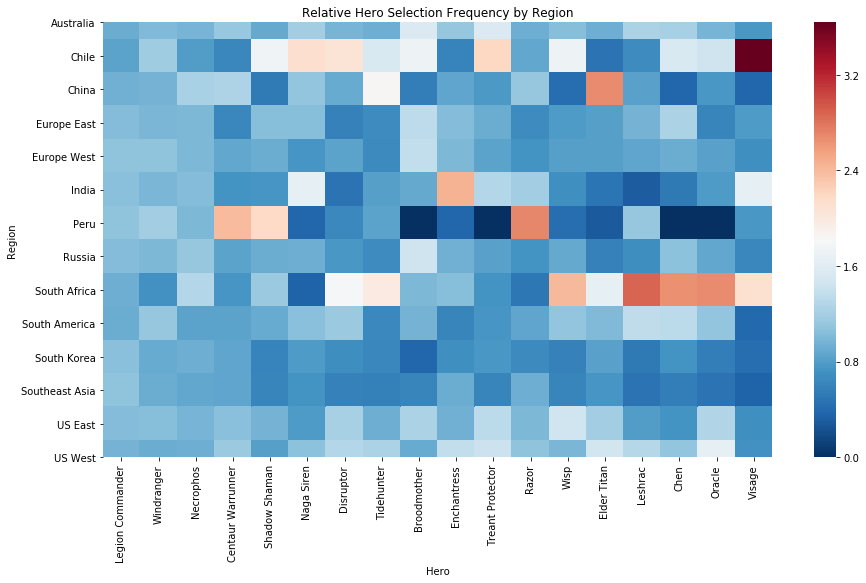

```python
fig, ax = plt.subplots(figsize=(15,8))
sns.heatmap(scaled_hero[list(hero_std.index[:3]) + list(hero_std.index[-15:])], ax=ax, cmap="RdBu_r")
ax.set_xlabel("Hero")
ax.set_title("Relative Hero Selection Frequency by Region")
fig.show()
```

Evidently, the characters that have the most variance are different this time around. Again, the three on the left have the least variance and the 15 on the right have the most. For the three on the left, all values are close to one, as expected. That is, each region selected Legion Commander the expected number of times. On the right side, Chile appears to use Visage much more than other regions. It is likely that the significant variance in some of these characters, especially those where regions like Chile or South Africa are strongly preferring a character, is due to the small sample size of the country.

## Predicting Game Outcome

We saw earlier that certain characters had much higher win rates than others. Given a match up two teams of five, can we possibly determine whether the team will win or not?

To do this, we will first take our training and testing dataframes and extract our input elements and output values out. Our input elements will be the indicator columns for all the heros with the outputs the Win/Loss column

```python
heros_train = train_df.drop(columns[:-len(heroes_list)], axis=1)
heros_test = test_df.drop(columns[:-len(heroes_list)], axis=1)

X_train = heros_train.values
X_test = heros_test.values

y_train = list(train_df['Win/Lose'])
y_test = list(test_df['Win/Lose'])
```

We tried multiple different models and hyper parameters, but our results across all of them were relatively similar. Generally, our score, that is how well we were able to predict the game outcome, was about 0.56. While hero choice may have some bearing on game outcome, it really does come down to skill. We looked at the models: logistic regression, SVM, MLP Classifier (using adam, sgd, lbfgs).

```python
LR = LogisticRegression(random_state=0, solver='lbfgs', multi_class='ovr').fit(X_train, y_train)
LR.predict(X_test)
round(LR.score(X_test,y_test), 4)
```

```
0.5636
```

```python
SVM = svm.LinearSVC()
SVM.fit(X_train, y_train)
SVM.predict(X_test)
round(SVM.score(X_test, y_test), 4)
```

```
0.5637
```

```python
NN = MLPClassifier(solver='adam', alpha=1e-5, hidden_layer_sizes=(20, 2), random_state=1, learning_rate_init = 0.001)
NN.fit(X_train, y_train)
NN.predict(X_test)
round(NN.score(X_test,y_test), 5)
```

```
0.54494
```

```python
NN = MLPClassifier(solver='sgd', alpha=1e-5, hidden_layer_sizes=(10, 1), random_state=1, momentum=0.9)
NN.fit(X_train, y_train)
NN.predict(X_test)
round(NN.score(X_test,y_test), 5)
```

```
0.501
```

```python
NN = MLPClassifier(solver='lbfgs', alpha=1e-5, hidden_layer_sizes=(5, 2), random_state=1, verbose=True)
NN.fit(X_train, y_train)
NN.predict(X_test)
round(NN.score(X_test,y_test), 5)
```

```
0.55598
```

[figure not shown]

```python
model = LogisticRegression(random_state=0, solver='lbfgs', multi_class='ovr').fit(X_train, y_train)

fig, ax = plt.subplots()
visualizer = LearningCurve(model, cv=5, ax=ax)
visualizer.fit(X_train, y_train)
ax.set_ylabel('Score')
ax.set_xlabel('Training Instances')
ax.set_title("Learning Curve Logistic Regression; solver LBFGS")
ax.legend()
fig.show()
```